# Effection of swapping on the multinomial example

### Complex problems are often broken down into smaller, simpler ones. Therefore, let’s first consider the following scenario: Given a 2x10 marginal table corresponding to micro-data, can we determine all potential marginal tables (also known as the support) that can be obtained through exchange algorithms?

### Let us use a simple example as follows:

| Q1 | Q2 |
| --- | --- |
| 1 | Y |
| 1 | Y |
| 1 | Y |
| 1 | Y |
| 1 | Y |
| 1 | Y |
| 1 | N |
| 0 | Y |
| 0 | Y |
| 0 | N |

### Corresponding marginal table:

$$\begin{pmatrix}
6 & 1 \\
2 & 1 \\
\end{pmatrix}$$

### So what are all the potential marginal forms (supports) that can be created through swapping?

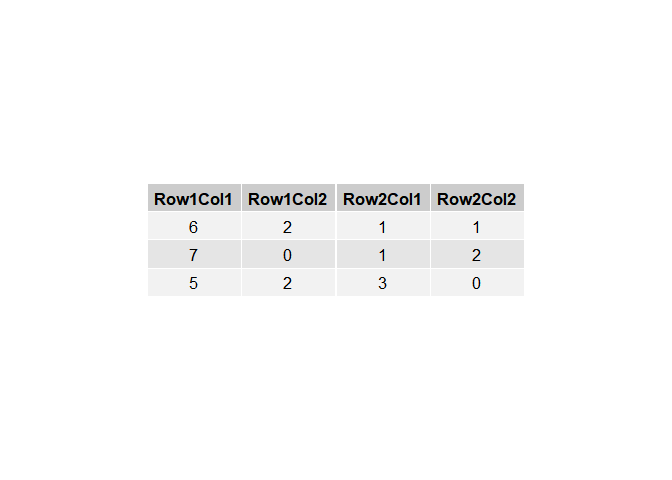

```r
generate_swaps <- function(margin_table) {
  # Generate all possible margin tables by swapping

  # Extract values from the margin table
  a <- margin_table[1,1]
  b <- margin_table[1,2]
  c <- margin_table[2,1]
  d <- margin_table[2,2]

  # Ensure the swaps are valid (non-negative counts)
  swaps <- list(
    matrix(c(a+1, b-1, c-1, d+1), nrow=2),
    matrix(c(a-1, b+1, c+1, d-1), nrow=2),
    margin_table
  )

  valid_swaps <- lapply(swaps, function(x) {
    if (all(x >= 0)) return(x) else return(NULL)
  })

  return(Filter(Negate(is.null), valid_swaps))
}

get_support <- function(margin_table, support_set = list()) {
  # Recursive function to get the full support set

  # Convert margin table to string to use as a unique key
  key <- paste(margin_table, collapse = ",")

  # If the margin table is already in the support set, return the support set
  if (key %in% names(support_set)) {
    return(support_set)
  }

  # Add the margin table to the support set
  support_set[[key]] <- margin_table

  # Get all possible swaps for the current margin table
  swaps <- generate_swaps(margin_table)

  # Recursively add swaps to the support set
  for (swap in swaps) {
    support_set <- get_support(swap, support_set)
  }

  return(support_set)
}

# Given example margin table
example_margin <- matrix(c(6, 1, 2, 1), nrow=2)

# Get the support set for the example
support_set <- get_support(example_margin)

# change support_set into df
support_df <- do.call(rbind, lapply(support_set, function(x) c(x[1,1], x[1,2], x[2,1], x[2,2])))
colnames(support_df) <- c("Row1Col1", "Row1Col2", "Row2Col1", "Row2Col2")


tg <- tableGrob(support_df, rows = NULL)

# Draw the table
grid.draw(tg)
```

```r
derangr <- function(x){
  v = 1:length(x)
  while(TRUE){
    xp <- sample(v)
    if(sum(xp == v) == 0) break
  }
  return(x[xp])
}

simulate_swaps <- function(initial_margin, p, n=10000){
  results <- list()

  # Convert marginal table into microdata
  microdata <- c(rep("1|1", initial_margin[1,1]),
                 rep("0|1", initial_margin[1,2]),
                 rep("1|0", initial_margin[2,1]),
                 rep("0|0", initial_margin[2,2]))

  for(i in 1:n){
    # Copy microdata
    current_data <- microdata

    # 2nd column
    second_col <- substr(current_data, 3, 3)

    # Choose rows with p
    selected_rows <- which(runif(length(second_col)) <= p)

    # Implement the derangement function
    if(length(selected_rows) > 1){
      second_col[selected_rows] <- derangr(second_col[selected_rows])
    }

    # Update the microdata
    current_data <- paste0(substr(current_data, 1, 1), "|", second_col)

    # Calculate the new marginal table
    key <- paste(c(sum(current_data == "1|1"), sum(current_data == "1|0"), sum(current_data == "0|1"), sum(current_data == "0|0")), collapse = ",")

    # Update the list(S|X)
    if(!is.null(results[[key]])){
      results[[key]] <- results[[key]] + 1
    } else {
      results[[key]] <- 1
    }
  }

  return(results)
}

initial_margin <- matrix(c(6, 1, 2, 1), nrow=2)
p <- 0.5
results <- simulate_swaps(initial_margin, p, 10000)
results
```

```
## $`6,1,2,1`
## [1] 6157
##
## $`5,2,3,0`
## [1] 3065
##
## $`7,0,1,2`
## [1] 778
```

Then plot the graph in reverse order of frequency

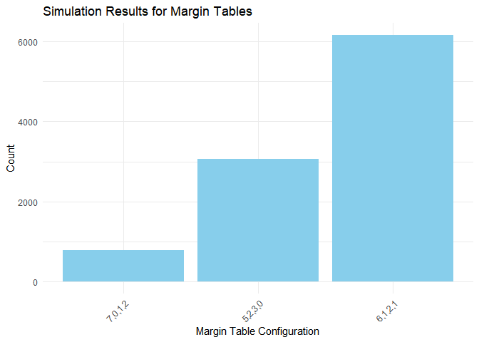

```r
# Convert the results list to a data frame
df <- data.frame(
  MarginTable = names(results),
  Count = unlist(results)
)

# Order the data frame by Count
df <- df[order(df$Count), ]

# Plot the data
ggplot(df, aes(x = reorder(MarginTable, Count), y = Count)) +
  geom_bar(stat = "identity", fill = "skyblue") +
  labs(title = "Simulation Results for Margin Tables",
       x = "Margin Table Configuration",
       y = "Count") +
  theme_minimal() +
  theme(axis.text.x = element_text(angle = 45, hjust = 1))
```

### Next we use a slightly more complex example. The marginal table of this example is as follows:

$$\begin{pmatrix}
10 & 5 \\
10 & 5 \\
\end{pmatrix}$$

Experiment with the same settings

### Support:

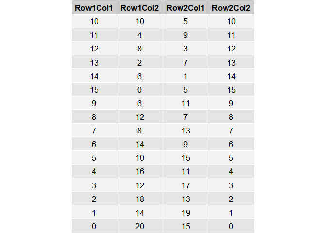

**Next we use Monte Carlo simulation to approximate S|X in the simpler case.** Here we use $p = 0.5$ to facilitate observation of the results. The initial marginal table is still $(10,5,10,5)$.

### Simulation result:

```r
# Helper function: Calculate the distance between two marginal tables
calculate_distance <- function(margin1, margin2) {
  abs(margin1[1,1] - margin2[1,1])
}

# Simulation function
simulate_swaps <- function(initial_margin, p, n=10000) {
  results <- list()

  # Convert initial marginal table to micro data
  microdata <- c(rep("1|1", initial_margin[1,1]),
                 rep("0|1", initial_margin[1,2]),
                 rep("1|0", initial_margin[2,1]),
                 rep("0|0", initial_margin[2,2]))

  for(i in 1:n) {
    # Copy microdata
    current_data <- microdata

    # Extract the second column
    second_col <- substr(current_data, 3, 3)

    # Select rows for swapping based on probability p
    selected_rows <- which(runif(length(second_col)) <= p)

    # Apply derangement function
    if(length(selected_rows) > 1) {
      second_col[selected_rows] <- derangr(second_col[selected_rows])
    }

    # Update microdata
    current_data <- paste0(substr(current_data, 1, 1), "|", second_col)

    # Calculate new margin table
    new_margin <- matrix(c(sum(current_data == "1|1"), sum(current_data == "0|1"),
                           sum(current_data == "1|0"), sum(current_data == "0|0")), nrow=2)

    # Calculate distance
    distance <- calculate_distance(initial_margin, new_margin)

    # Update result list
    key <- paste(c(new_margin[1,1], new_margin[1,2], new_margin[2,1], new_margin[2,2], distance), collapse = ",")
    if(!is.null(results[[key]])) {
      results[[key]] <- results[[key]] + 1
    } else {
      results[[key]] <- 1
    }
  }

  return(results)
}

# Simulation
initial_margin <- matrix(c(10,5,10,5), nrow=2)
p <- 0.5
results <- simulate_swaps(initial_margin, p, 10000)

# Convert results to dataframe and add distance column
df <- data.frame(
  MarginTable = names(results),
  Count = unlist(results),
  Distance = sapply(strsplit(names(results), ","), function(x) as.numeric(x[5]))
)

# Sort by Count column in descending order
df_sorted <- df[order(-df$Count), ]

print(df_sorted, row.names = FALSE)
```

```
##  MarginTable Count Distance
##  10,5,10,5,0  3424        0
##   11,4,9,6,1  2443        1
##   9,6,11,4,1  2349        1
##   12,3,8,7,2   778        2
##   8,7,12,3,2   766        2
##   13,2,7,8,3   118        3
##   7,8,13,2,3   106        3
##   6,9,14,1,4    10        4
##   14,1,6,9,4     6        4
```

From the descending count table, we can clearly see that as the distance increases, the frequency gradually decreases.

To be more intuitive, let’s draw a plot:

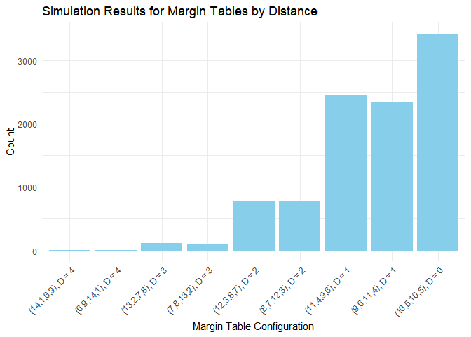

```r
# Simulation
initial_margin <- matrix(c(4,6,8,10), nrow=2)
p <- 1
results <- simulate_swaps(initial_margin, p, 10000)

# Convert results to dataframe and add distance column
df <- data.frame(
  MarginTable = names(results),
  Count = unlist(results),
  Distance = sapply(strsplit(names(results), ","), function(x) as.numeric(x[5]))
)

# Sort by Count column in descending order
df_sorted <- df[order(-df$Count), ]

print(df_sorted, row.names = FALSE)
```

```
##  MarginTable Count Distance
##   4,6,8,10,0  3085        0
##   5,5,7,11,1  2609        1
##    3,7,9,9,1  1897        1
##   6,4,6,12,2  1270        2
##   2,8,10,8,2   667        2
##   7,3,5,13,3   326        3
##   1,9,11,7,3    94        3
##   8,2,4,14,4    45        4
##  0,10,12,6,4     4        4
##   9,1,3,15,5     3        5
```

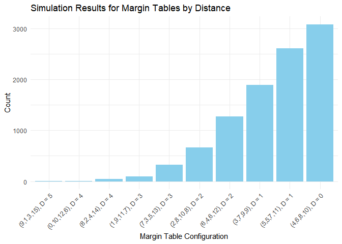

```r
# Convert into data frame
df <- data.frame(
  MarginTable = names(results),
  Count = unlist(results),
  Distance = as.numeric(sapply(strsplit(names(results), ","), function(x) x[5]))
)

# Format MarginTable column, add brackets and remove d values
df$MarginTableFormatted <- gsub("(.+),(.+),(.+),(.+),(.+)", "(\\1,\\2,\\3,\\4), D = \\5", df$MarginTable)

# Sort by distance and count
df <- df[order(df$Distance, df$Count, decreasing = TRUE), ]

# Draw plot
ggplot(df, aes(x = reorder(MarginTableFormatted, -Distance), y = Count)) +
  geom_bar(stat = "identity", fill = "skyblue") +
  labs(title = "Simulation Results for Margin Tables by Distance",
       x = "Margin Table Configuration",
       y = "Count") +
  theme_minimal() +
  theme(axis.text.x = element_text(angle = 45, hjust = 1))
```

Now, as the distance increases, the frequency appears to gradually decrease.

**In our previous experiments, we learned how to determine the support for potential marginal tables that can be obtained through a swapping algorithm. Additionally, using Monte Carlo simulations, we estimated the likelihood of obtaining each marginal table given a specific margin and swap rate. Upon further observation, we also discerned the frequency patterns of obtaining marginal tables with varying ‘distances’ under different swap rates through the swapping algorithm.**

## Experiment Design: Statistical Inference Using Approximate Bayesian Computation (ABC)

### Objective

This experiment aims to perform statistical inference on a specific dataset using the Approximate Bayesian Computation (ABC) method. Given a dataset $S_{\text{obs}}$ is an $n \times 2$ data matrix, which can also be transformed into a $2 \times 2$ marginal table.

### Methodology

1. **Prior Probability Setting**: We assume that the parameter $\theta^{(i)}$ follows a Dirichlet distribution, i.e.,
   $$\theta^{(i)}
   \sim \text{Dir}(1, 1, 1, 1).$$
2. **Data Generation Process**: Given the parameter $\theta^{(i)}$, we generate multinomial distribution data $X^{(i)}$, i.e.,
   $$X^{(i)} | \theta^{(i)} \sim \text{Mult}(n,
   \theta).$$
   Here, $X^{(i)}$ is an $n \times 2$ data matrix.
3. **Data Swapping Process**: Given the data $X^{(i)}$, we apply a swapping algorithm $\eta_p(S | X)$ with a swapping rate $p$. This process involves fixing one column of data and permuting the other.
4. **Acceptance/Rejection Criterion**: In each iteration, we compare the observed marginal table $S_{\text{obs}}$ with the marginal table $S^{(i)}$ obtained through the swapping algorithm. If $S_{\text{obs}} = S^{(i)}$, we retain the current parameter $\theta^{(i)}$; otherwise, we skip the current iteration.

### Expected Outcome

Through multiple iterations (100,000 times), we expect to obtain **the distribution of the parameter $\theta$ concerning the observed data $S_{\text{obs}}$**. This distribution will reflect the uncertainty and range of variation of the parameters given the observed data.

In the experiment, we use a dataset $S_{\text{obs}} = \begin{pmatrix} 1 & 2 \\ 3 & 4 \end{pmatrix}$, then theoretically θ should gradually increase.

```r
# Set parameters
S_obs <- matrix(c(1, 2, 3, 4), nrow = 2) # Observed marginal table
n <- sum(S_obs) # Total number of observations
p <- 0.1 # Swap rate
iterations <- 100000 # Number of iterations
theta_prior <- c(1, 1, 1, 1) # Prior distribution parameters

# Function to generate a derangement (permutation with no fixed points)
derangr <- function(x) {
  v = 1:length(x)
  while(TRUE) {
    xp <- sample(v)
    if(sum(xp == v) == 0) break
  }
  return(x[xp])
}


# Function to convert 2x2 marginal table to n*2 data format
marginal_to_microdata <- function(marginal_table) {
  microdata <- matrix(nrow = 0, ncol = 2)
  for (row in 1:nrow(marginal_table)) {
    for (col in 1:ncol(marginal_table)) {
      cell_data <- matrix(rep(c(row - 1, col - 1), marginal_table[row, col]), ncol = 2, byrow = TRUE)
      microdata <- rbind(microdata, cell_data)
    }
  }
  return(microdata)
}

# Initialize a list to store accepted theta values
accepted_thetas <- list()

# Iteration process
for (i in 1:iterations) {
  # Generate theta from the prior distribution
  theta <- rdirichlet(1, theta_prior)

  # Generate X
  X <- rmultinom(n, 1, theta)
  X <- t(X)

  # Constructing the 2x2 Marginal Table
  X_marginal <- matrix(c(sum(X[,1]), sum(X[,2]), sum(X[,3]), sum(X[,4])), nrow=2)

  # Convert X_marginal to microdata
  X_microdata <- marginal_to_microdata(X_marginal)

  # Swap process
  swap_indicator <- rbinom(nrow(X_microdata), 1, p)
  swap_rows <- which(swap_indicator == 1)
  if (length(swap_rows) > 1) {
    swapped_values <- derangr(X_microdata[swap_rows, 2])
    X_microdata[swap_rows, 2] <- swapped_values
  }

  # Construct S_marginal from swapped microdata
  S_marginal <- matrix(0, nrow=2, ncol=2)
  for (row in 0:1) {
    for (col in 0:1) {
      S_marginal[row + 1, col + 1] <- sum(X_microdata[,1] == row & X_microdata[,2] == col)
    }
  }

  # Check if swapped data matches observed data
  if (all(S_marginal == S_obs)) {
    accepted_thetas[[length(accepted_thetas) + 1]] <- theta
  }
}
```

### Let’s plot the empirical density estimate of $θ$：

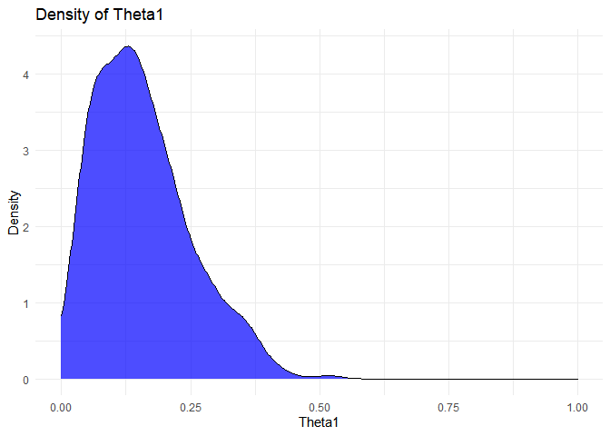

```r
theta1_values <- sapply(accepted_thetas, function(x) x[1])
ggplot(data.frame(theta1 = theta1_values), aes(x = theta1)) +
    geom_density(fill="blue", alpha=0.7) +
    labs(title = "Density of Theta1", x = "Theta1", y = "Density") +
    theme_minimal() +
    xlim(0, 1)
```

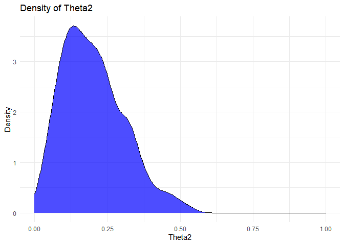

```r
theta2_values <- sapply(accepted_thetas, function(x) x[2])
ggplot(data.frame(theta2 = theta2_values), aes(x = theta2)) +
    geom_density(fill="blue", alpha=0.7) +
    labs(title = "Density of Theta2", x = "Theta2", y = "Density") +
    theme_minimal() +
    xlim(0, 1)
```

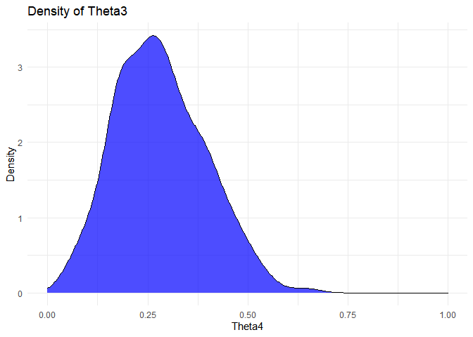

```r
theta3_values <- sapply(accepted_thetas, function(x) x[3])
ggplot(data.frame(theta3 = theta3_values), aes(x = theta3)) +
    geom_density(fill="blue", alpha=0.7) +
    labs(title = "Density of Theta3", x = "Theta4", y = "Density") +
    theme_minimal() +
    xlim(0, 1)
```

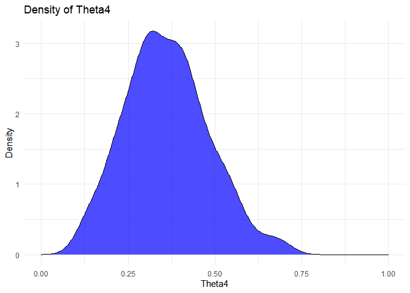

```r
theta4_values <- sapply(accepted_thetas, function(x) x[4])
ggplot(data.frame(theta4 = theta4_values), aes(x = theta4)) +
    geom_density(fill="blue", alpha=0.7) +
    labs(title = "Density of Theta4", x = "Theta4", y = "Density") +
    theme_minimal() +
    xlim(0, 1)
```

We can see the expected conclusions from the figure. However, due to the low acceptance rate, even after many iterations (100,000 times), the effect is still not very good.

### And our previous statistic φ (due to some outliers, we only show φ ≤ 10):

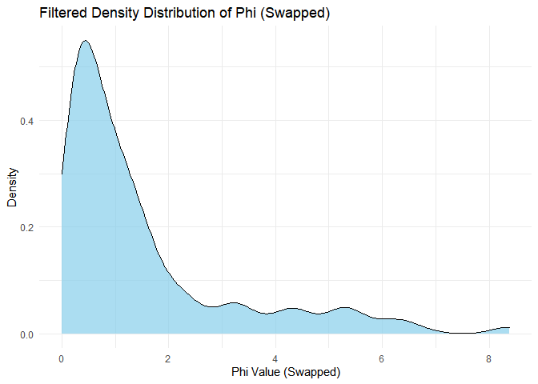

```r
phi_values <- sapply(accepted_thetas, function(theta) {
  theta1 <- theta[1]
  theta2 <- theta[2]
  theta3 <- theta[3]
  theta4 <- theta[4]
  return((theta1 * theta4) / (theta2 * theta3))
})

# Truncated to 10
filtered_phi_values <- phi_values[abs(phi_values) <= 10]

ggplot(data.frame(filtered_phi_values), aes(x=filtered_phi_values)) +
  geom_density(fill="skyblue", alpha=0.7) +
  labs(title="Filtered Density Distribution of Phi (Swapped)", x="Phi Value (Swapped)", y="Density") +
  theme_minimal()
```

Then we try 5,000,000 times iterations and see the performance:

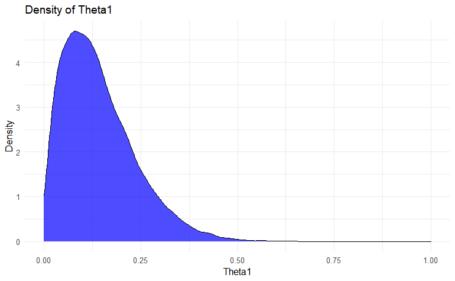

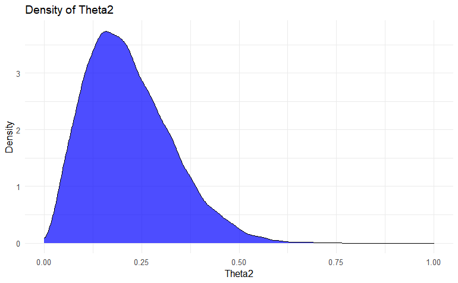

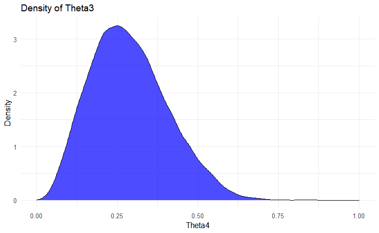

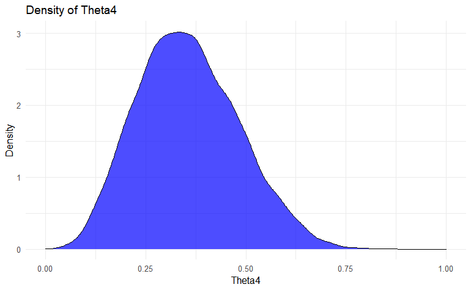

The image of $θ$ becomes smoother and closer to the real value, since theoretically $θ$ should be $(0.1,0.2,0.3,0.4)$.

To encompass more uncertainties in our experiment, we have designed the following procedure:

Assume our true parameter set $\theta^*$ is $(0.1, 0.2, 0.3, 0.4)$. Then, $S^*$ given $\theta^*$, denoted as $S^* | \theta^*$, is generated from a multinomial distribution $\text{Mult}(\theta^*)$. Due to the inherent uncertainty in this process, we repeat the sampling **10** times to produce different instances of $S^*$.

Subsequently, for each $S^*$, we obtain $S_{\text{obs}}$ given $S^*$ and a swapping rate $p$, which is precisely the outcome of our swapping algorithm. With $S_{\text{obs}}$ in hand, we can proceed with the Approximate Bayesian Computation (ABC) as per our previous experimental design.

To validate the power of the experiment, it is necessary to record the acceptance rate and examine the impact of different settings on this rate. Therefore, in the experiment, we iterate 100,000 times for different swapping rates $p$, and different $\theta^*$ sets to observe their respective acceptance rates.

```r
ABC_simulation <- function(S_obs, p, iterations, theta_star, theta_prior, save_results = FALSE, result_prefix = "ABC_result") {
  # Total number of observations
  n <- sum(S_obs)

  # Function to generate a derangement
  derangr <- function(x) {
    v = 1:length(x)
    while(TRUE) {
      xp <- sample(v)
      if(sum(xp == v) == 0) break
    }
    return(x[xp])
  }

  # Function to convert 2x2 marginal table to n*2 data format
  marginal_to_microdata <- function(marginal_table) {
    microdata <- matrix(nrow = 0, ncol = 2)
    for (row in 1:nrow(marginal_table)) {
      for (col in 1:ncol(marginal_table)) {
        cell_data <- matrix(rep(c(row - 1, col - 1), marginal_table[row, col]), ncol = 2, byrow = TRUE)
        microdata <- rbind(microdata, cell_data)
      }
    }
    return(microdata)
  }

  # Initialize a list to store accepted theta values and a counter for accepted iterations
  accepted_thetas <- list()
  accepted_count <- 0

  # Iteration process
  for (i in 1:iterations) {
    # Generate theta from the prior distribution
    theta <- rdirichlet(1, theta_prior)

    # Generate X
    X <- rmultinom(n, 1, theta)
    X <- t(X)

    # Constructing the 2x2 Marginal Table
    X_marginal <- matrix(c(sum(X[,1]), sum(X[,2]), sum(X[,3]), sum(X[,4])), nrow=2)

    # Convert X_marginal to microdata
    X_microdata <- marginal_to_microdata(X_marginal)

    # Swap process
    swap_indicator <- rbinom(nrow(X_microdata), 1, p)
    swap_rows <- which(swap_indicator == 1)
    if (length(swap_rows) > 1) {
      swapped_values <- derangr(X_microdata[swap_rows, 2])
      X_microdata[swap_rows, 2] <- swapped_values
    }

    # Construct S_marginal from swapped microdata
    S_marginal <- matrix(0, nrow=2, ncol=2)
    for (row in 0:1) {
      for (col in 0:1) {
        S_marginal[row + 1, col + 1] <- sum(X_microdata[,1] == row & X_microdata[,2] == col)
      }
    }

    # Check if swapped data matches observed data
    if (all(S_marginal == S_obs)) {
      accepted_thetas[[length(accepted_thetas) + 1]] <- theta
      accepted_count <- accepted_count + 1
    }
  }

  # Calculate acceptance rate
  acceptance_rate <- accepted_count / iterations

  if (save_results) {
    # Generate filename containing S_obs, theta_prior, p, and iterations

    S_obs_label <- paste0("S_obs_", paste(S_obs, collapse = "_"))
    theta_label <- paste0("theta_star_", paste(theta_star, collapse = "_"))
    p_label <- paste0("p_", p)
    iter_label <- paste0("iter_", iterations)
    filename <- paste0("C:/Users/14817/Desktop/Research/Ddifferential Privacy/DPswapping_files/Accepted thetas/", result_prefix, "_", S_obs_label, "_", theta_label, "_", p_label, "_", iter_label, ".RData")

    # Save result
    save(accepted_thetas, file = filename)
  }

  return(list("Accepted Thetas" = accepted_thetas, "Acceptance Rate" = acceptance_rate))
}

# Function to apply the swapping algorithm
apply_swapping_algorithm <- function(margin_table, p) {
  # marginal 2 microdata
  microdata <- c(rep("1|1", margin_table[1,1]),
                 rep("0|1", margin_table[1,2]),
                 rep("1|0", margin_table[2,1]),
                 rep("0|0", margin_table[2,2]))

  # apply swapping
  for(i in 1:nrow(margin_table)) {
    # generate the indicater
    swap_indicator <- rbinom(length(microdata), 1, p)
    selected_rows <- which(swap_indicator == 1)

    # apply the derangement
    if(length(selected_rows) > 1) {
      second_col <- substr(microdata[selected_rows], 3, 3)
      swapped_values <- derangr(second_col)
      microdata[selected_rows] <- paste0(substr(microdata[selected_rows], 1, 1), "|", swapped_values)
    }
  }

  # microdata 2 marginal
  new_margin <- matrix(c(sum(microdata == "1|1"), sum(microdata == "0|1"),
                         sum(microdata == "1|0"), sum(microdata == "0|0")), nrow=2)

  return(new_margin)
}
```

```r
# Function to iterate over different θ* and p
run_experiments <- function(theta_star_list, p_list, n, iterations, theta_prior, experiment_repeats) {
  results <- data.frame()
  for (theta_star in theta_star_list) {
    for (p in p_list) {
      acceptance_rates <- numeric(experiment_repeats)
      for (i in 1:experiment_repeats) {
        S_star <- rmultinom(1, n, theta_star)
        S_star <- matrix(S_star, nrow = 2)
        S_obs <- apply_swapping_algorithm(S_star, p)
        ABC_results <- ABC_simulation(S_obs, p, iterations, theta_star, theta_prior, save_results = TRUE)
        acceptance_rates[i] <- ABC_results$'Acceptance Rate'
      }
      avg_acceptance_rate <- mean(acceptance_rates)
      results <- rbind(results, data.frame(Theta_Star = toString(theta_star), Swap_Rate = p, Acceptance_Rate = avg_acceptance_rate))
    }
  }
  return(results)
}

# Setting
theta_star_list <- list(c(0.1, 0.2, 0.3, 0.4), c(0.7, 0.1, 0.1, 0.1), c(0.27, 0.23, 0.23, 0.27), c(0.25, 0.25, 0.25, 0.25))
p_list <- c(0.1, 0.2, 0.3, 0.4, 0.5, 0.6, 0.7, 0.8, 0.9, 1)

# Run the experiment
experiment_results <- run_experiments(theta_star_list, p_list, 10, 100000, c(1, 1, 1, 1), 10)

experiment_results
```

```
##                Theta_Star Swap_Rate Acceptance_Rate
## 1      0.1, 0.2, 0.3, 0.4       0.1        0.003709
## 2      0.1, 0.2, 0.3, 0.4       0.2        0.004059
## 3      0.1, 0.2, 0.3, 0.4       0.3        0.003971
## 4      0.1, 0.2, 0.3, 0.4       0.4        0.004306
## 5      0.1, 0.2, 0.3, 0.4       0.5        0.004089
## 6      0.1, 0.2, 0.3, 0.4       0.6        0.005454
## 7      0.1, 0.2, 0.3, 0.4       0.7        0.005027
## 8      0.1, 0.2, 0.3, 0.4       0.8        0.004937
## 9      0.1, 0.2, 0.3, 0.4       0.9        0.004911
## 10     0.1, 0.2, 0.3, 0.4       1.0        0.004239
## 11     0.7, 0.1, 0.1, 0.1       0.1        0.003580
## 12     0.7, 0.1, 0.1, 0.1       0.2        0.003582
## 13     0.7, 0.1, 0.1, 0.1       0.3        0.003907
## 14     0.7, 0.1, 0.1, 0.1       0.4        0.004190
```

[output cut: 26 more lines]

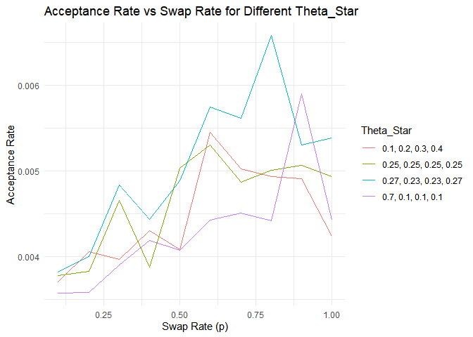

```r
ggplot(experiment_results, aes(x = Swap_Rate, y = Acceptance_Rate, group = Theta_Star, color = Theta_Star)) +
  geom_line() +
  labs(title = "Acceptance Rate vs Swap Rate for Different Theta_Star",
       x = "Swap Rate (p)",
       y = "Acceptance Rate",
       color = "Theta_Star") +
  theme_minimal()
```